# 2017 Statistics Midterm Exam1

地理二 B06208001 龔泓愷

2018年10月14日

## Q1

台北市某高中一行共 5 人，放學後相約在學校門口旁的 自行車租借站(A 站)，結伴騎乘公共自行車，到西門町(租借站 B 站)聚餐與逛街。

已知 1：  
A 站有 20 個車位，每個車位有腳踏車的機率為 0.2；  
B 站有 40 個車位，每個車位有腳踏車的機率為 0.1。  
每個車位有無停放腳踏車皆是一個獨立事件。

已知 2：  
台北市所有流通的公共自行車共有 200 輛，其中 5% 有輕微損壞(仍租借使用)。  
校方為了確保學生的交通安全，與自行車租賃業者合作進行調查，  
發現在所有輕微損壞的自行車中，有 10% 會出現在該校門口旁的 A 站。

1. 這 5 位好友每個人同時都能在 A 站借車，且在 B 站能同時還車的機率。  
   腳踏車是否能借為二項分布。  
   A = 五人都能在A站借到車的機率 = P(A可借 >= 5) = 1 - P(A可借<= 4)  
   B = 五人都能在B站還到車的機率 = P(B可還 >= 5) = 1 - P(B可還<= 4)

```r
A = pbinom(4, size = 20, prob = 0.2, lower.tail = F)
B = pbinom(4, size = 40, prob = 0.9, lower.tail = F)
A * B
```

```
## [1] 0.3703517
```

**5 位好友每個人同時都能在 A 站借車，且在 B 站能同時還車的機率0.3703517**。

2. 小明在 A 站會租到輕微損壞自行車的機率。  
   A = A站有腳踏車  
   B = 有壞的腳踏車  
   P(A) = 20 * 0.2 /200 = 0.02  
   P(B) = 0.05  
   P(A|B) = 0.1  
   題目為P(B|A) = P(A|B) * P(B) / P(A)

```r
0.1 * 0.05 / 0.02
```

```
## [1] 0.25
```

**小明在 A 站會租到輕微損壞自行車的機率0.25**。

3. 這 5 位好友中有 2 人在 A 站剛好租到輕微損壞自行車的機率。

```r
dbinom(2, size = 5, prob = 0.25)
```

```
## [1] 0.2636719
```

**這 5 位好友中有 2 人在 A 站剛好租到輕微損壞自行車的機率為0.2636719**

## Q2

世貿捷運站晚上的每小時進出站人數是呈現常態分布。  
進站人數 (平均=80，標準差=5)；岀站人數 (平均=30，標準差=3)，  
且每小時的進出站人數互相獨立。

1. 該捷運站的設計容量是以每小時停留站內的平均人數加上 3 倍標準差。  
   計算該站可容納的人數。 (假設：站內人數 = 進站人數 – 出站人數)

因為進站人數與出站人數皆為常態分佈，站內人數亦為常態分佈。 mean(站內人數) = 80 - 30 = 50 sd(站內人數) = sqrt(5^2 + 3^2) = 5.830952

```r
sd = sqrt(5^2 + 3^2)
50 + 3 * sd
```

```
## [1] 67.49286
```

**該站可容納的人數為67人**

2. 為了因應跨年晚會人潮湧入捷運站，捷運局預估當晚每小時的進站人數會是平 日的 3 倍，而每小時出站人數則為平日的 0.5 倍。定義跨年尖峰站內人數為當晚 每小時站內的平均人數加上 3 倍標準差。計算該站的跨年尖峰站內人數。

當晚每小時進站人數 = 80 * 3 = 240  
其標準差為5 * 3 = 15  
當晚每小時出站人數 = 30 * 0.5 = 15  
其標準差為3 * 0.5 = 1.5

當晚每小時站內人數 = 240 - 15 = 225  
其標準差為sqrt(15^2 + 1.5^2) = 15.0741

```r
sd = sqrt(15^2 + 1.5^2)
225 + 3 * sd
```

```
## [1] 270.2244
```

**該站的跨年尖峰站內人數為270人**

3. 捷運局認為，若該站每小時站內人數超過 200 人，就需要加派人力引導疏散。  
   請分別計算在平日晚上和跨年晚會，該站需要加派人力的機率。

```r
pnorm(200, mean = 50, sd = 5.830952, lower.tail = F)
```

```
## [1] 3.08695e-146
```

```r
pnorm(200, mean = 225, sd = 15.0741, lower.tail = F)
```

```
## [1] 0.9513891
```

**平日晚上和跨年晚會，該站需要加派人力的機率分別為3.08695e-146與0.9513891**

## Q3

定義：每天遭竊率 (%) = (每天遭竊人數 / 總人口數) x 100%  
< 10% 良好 10%-30% 普通 31%-70% 不良 > 70% 危險  
若某城市有 100 萬人口，每人每天會遭竊的機率 0.01。

1. 協助繪製該城市「每天遭竊人數」的機率分布圖 (probability distribution function, PDF)，並分別以綠色、藍色、黃色和紅色在圖上標示出「良好」、「普 通」、「不良」、「危險」等區間。

是否遭竊為二項分布。  
A良好為 < 100000 人被竊。  
B普通為 100000 ~ 300000 人被竊。  
C不良為 300000 ~ 700000 人被竊。  
D危險為 > 700000 人被竊。

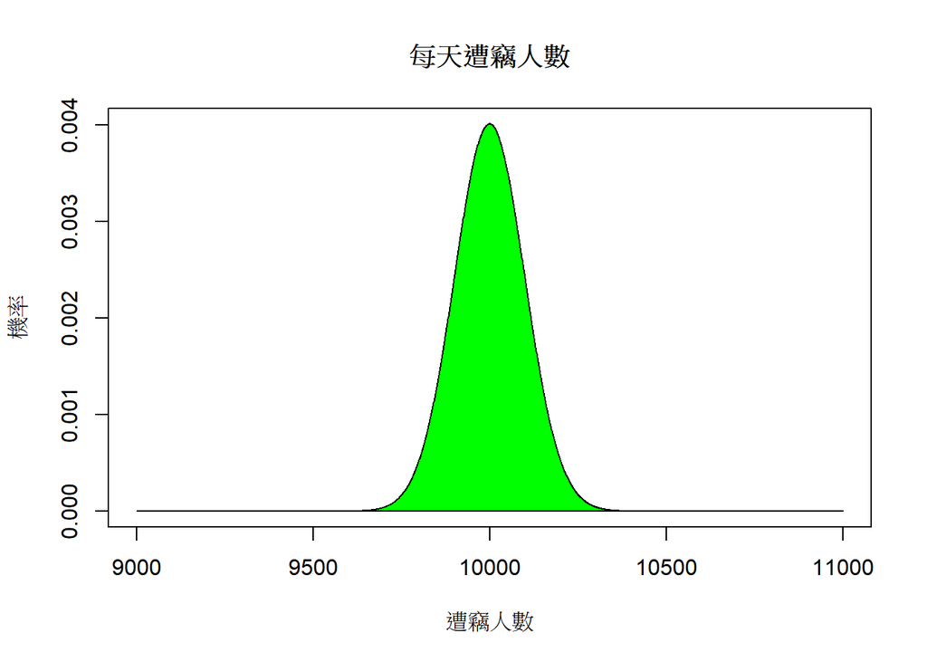

```r
xx = c(9000:11000)
yy = dbinom(xx, size = 1000000, prob = 0.01)
plot(x = xx, y = yy, type = "l", main = "每天遭竊人數", xlab = '遭竊人數', ylab = '機率')

region.x = xx[xx<=100000]
region.y = yy[xx<=100000]

region.x2 = c(head(region.x,1), region.x, tail(region.x,1))
region.y2 = c(0, region.y, 0)

polygon(region.x2, region.y2, col = "green")
```

**因為平均遭竊人數遠小於安全標準，不必要畫其他區域**

2. 模擬在一年(365 天)中的「每天遭竊人數」，並計算在這一年當中，「每天遭竊人  
   數」會超出離群值(outlier)的日數。

```r
data = rbinom(365, size = 1000000, prob = 0.01)
Q1T <- quantile(data)[2] - 1.5 * IQR(data)
Q3T <- quantile(data)[4] + 1.5 * IQR(data)
count = 0
for (i in 1:365){
  if (data[i] < Q1T|data[i] > Q3T)
    count = count + 1
}
count
```

```
## [1] 2
```

**會超出離群值(outlier)的日數為上面(count)的天數**

3. 若該城市警察加強巡邏，將每人每天會遭竊的機率降低為 0.001。  
   重新繪製 a 小題的機率分布圖，並比較與描述兩張統計圖的差異。

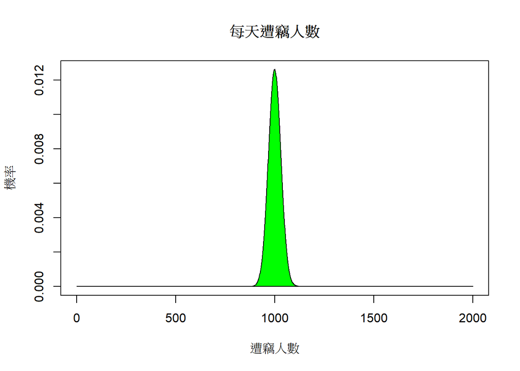

```r
xx = c(0:2000)
yy = dbinom(xx, size = 1000000, prob = 0.001)
plot(x = xx, y = yy, type = "l", main = "每天遭竊人數", xlab = '遭竊人數', ylab = '機率')

region.x = xx[xx<=100000]
region.y = yy[xx<=100000]

region.x2 = c(head(region.x,1), region.x, tail(region.x,1))
region.y2 = c(0, region.y, 0)

polygon(region.x2, region.y2, col = "green")
```

**竊盜率更低，與(a)比較中心位置轉變，且標準差更小(X軸同樣為2000)**